```python
%matplotlib inline
import pickle
import numpy as np
import pandas as pd
import matplotlib
import matplotlib.pyplot as plt
import scipy
from scipy import stats
plt.rcParams["figure.figsize"] = (10,8)
```

# Lab 5

**with LHC particle physics data set 2**

Higgs Classification In this project we are going to look at an inclusive search for the standard model Higgs boson in pp collisions at √ s = 13 TeV at the LHC using simulated data [A. Schuy]. The Higgs bosons are produced with large transverse momentum (pT) and decaying to a bottom quark-antiquark pair. The Higgs candidates could be reconstructed as large-radius jets using Calorimeters. Due to large QCD backgorund containmination, the direct 5-sigma observation of this Higgs channel is not accomplished yet[Phys. Rev. Lett. 120, 071802 (2018)]. We are going to use a set of training datasets to optimize event selections in order to enhance the discovery sensitivity. The optimal event selections will be applied to a selected pseudo-experiment data.

Both of you will use the same training samples for analysis. Each sample contains 14 features: ‘pt', 'eta', 'phi', 'mass', 'ee2', 'ee3', 'd2', 'angularity', 't1', 't2', 't3', 't21', 't32', 'KtDeltaR' [Eur. Phys. J. C 79 (2019) 836]. You can explore different strategies for event selection optimization using training samples. The optimal event selection will be applied to pseudo-experiment data.

```python
# The signal dataset is labeled as “higgs”
higgs_file = open("higgs_100000_pt_1000_1200.pkl", 'rb')
higgs_dict = pickle.load(higgs_file)
```

```python
# The background dataset is labeled as “qcd”
qcd_file = open("qcd_100000_pt_1000_1200.pkl",'rb')
qcd_dict = pickle.load(qcd_file)
```

```python
higgs_dict.keys()
```

```
Index(['pt', 'eta', 'phi', 'mass', 'ee2', 'ee3', 'd2', 'angularity', 't1',
       't2', 't3', 't21', 't32', 'KtDeltaR'],
      dtype='object')
```

```python
qcd_dict.keys()
```

```
Index(['pt', 'eta', 'phi', 'mass', 'ee2', 'ee3', 'd2', 'angularity', 't1',
       't2', 't3', 't21', 't32', 'KtDeltaR'],
      dtype='object')
```

```python
higgs = pd.DataFrame(np.array(higgs_dict))
higgs.columns = [ 'pt', 'eta', 'phi', 'mass', 'ee2', 'ee3', 'd2', 'angularity', 't1', 't2', 't3', 't21', 't32', 'KtDeltaR']
higgs
```

|  | pt | eta | phi | mass | ee2 | ee3 | d2 | angularity | t1 | t2 | t3 | t21 | t32 | KtDeltaR |
| --- | --- | --- | --- | --- | --- | --- | --- | --- | --- | --- | --- | --- | --- | --- |
| 0 | 1130.533498 | 0.075569 | -2.535979 | 126.390705 | 0.050194 | 0.000198 | 1.565921 | 0.000846 | 0.710011 | 0.318588 | 0.201156 | 0.448709 | 0.631396 | 0.236212 |
| 1 | 1040.287356 | -0.917809 | -0.511002 | 125.735472 | 0.068068 | 0.000259 | 0.822408 | 0.000093 | 1.070693 | 0.243505 | 0.149150 | 0.227427 | 0.612512 | 0.223529 |
| 2 | 1042.978241 | 0.431547 | -1.287136 | 125.946948 | 0.054627 | 0.000189 | 1.159519 | 0.000493 | 0.707240 | 0.196842 | 0.161801 | 0.278324 | 0.821986 | 0.284253 |
| 3 | 1173.988224 | -1.000457 | -0.567291 | 133.475055 | 0.057164 | 0.000211 | 1.131290 | 0.000316 | 1.586268 | 0.213899 | 0.137810 | 0.134844 | 0.644277 | 0.216328 |
| 4 | 1158.143085 | -0.205305 | 2.778395 | 135.047319 | 0.028222 | 0.000114 | 5.084335 | 0.004804 | 0.644669 | 0.259307 | 0.242958 | 0.402232 | 0.936954 | 0.443097 |
| ... | ... | ... | ... | ... | ... | ... | ... | ... | ... | ... | ... | ... | ... | ... |
| 99995 | 1081.930827 | -0.292886 | -0.066601 | 128.449819 | 0.062010 | 0.000188 | 0.788336 | 0.000623 | 0.984561 | 0.132130 | 0.106621 | 0.134201 | 0.806947 | 0.223551 |
| 99996 | 1114.171856 | -0.071148 | -0.518420 | 128.133729 | 0.060090 | 0.000269 | 1.239701 | 0.000745 | 0.863711 | 0.297420 | 0.248208 | 0.344352 | 0.834536 | 0.224712 |
| 99997 | 1066.593095 | 0.776745 | -2.067399 | 125.351507 | 0.063063 | 0.000260 | 1.036221 | 0.000161 | 1.545428 | 0.230121 | 0.177881 | 0.148904 | 0.772991 | 0.231622 |
| 99998 | 1043.746312 | -0.403642 | 1.761954 | 125.477362 | 0.065217 | 0.000204 | 0.736390 | 0.000253 | 1.147794 | 0.208940 | 0.162744 | 0.182036 | 0.778902 | 0.222911 |
| 99999 | 1167.639118 | 0.372814 | -0.428271 | 123.796492 | 0.047734 | 0.000230 | 2.112183 | 0.000899 | 0.770626 | 0.288856 | 0.205439 | 0.374832 | 0.711216 | 0.179421 |

100000 rows × 14 columns

```python
qcd = pd.DataFrame(np.array(qcd_dict))
qcd.columns = [ 'pt', 'eta', 'phi', 'mass', 'ee2', 'ee3', 'd2', 'angularity', 't1', 't2', 't3', 't21', 't32', 'KtDeltaR']
qcd
```

|  | pt | eta | phi | mass | ee2 | ee3 | d2 | angularity | t1 | t2 | t3 | t21 | t32 | KtDeltaR |
| --- | --- | --- | --- | --- | --- | --- | --- | --- | --- | --- | --- | --- | --- | --- |
| 0 | 1034.181543 | 1.193191 | 2.942234 | 272.010881 | 0.102485 | 0.003492 | 3.244343 | 0.006256 | 0.961697 | 0.598986 | 0.425024 | 0.622843 | 0.709573 | 0.082995 |
| 1 | 1125.535509 | -1.833090 | 0.121390 | 139.794408 | 0.035430 | 0.000288 | 6.481473 | 0.000155 | 0.896003 | 0.633385 | 0.476566 | 0.706900 | 0.752412 | 0.439346 |
| 2 | 1099.223087 | 0.557867 | -1.238027 | 245.413146 | 0.099080 | 0.002563 | 2.634788 | 0.005682 | 0.861678 | 0.486505 | 0.264631 | 0.564602 | 0.543942 | 0.251453 |
| 3 | 1118.230032 | 1.505473 | 1.953123 | 89.975916 | 0.017950 | 0.000077 | 13.389845 | 0.000432 | 0.952917 | 0.856141 | 0.730438 | 0.898442 | 0.853175 | 0.121666 |
| 4 | 1059.907996 | -0.387179 | -1.064832 | 85.893956 | 0.018515 | 0.000072 | 11.342156 | 0.002575 | 0.868770 | 0.645362 | 0.484853 | 0.742845 | 0.751289 | 0.386788 |
| ... | ... | ... | ... | ... | ... | ... | ... | ... | ... | ... | ... | ... | ... | ... |
| 99995 | 1185.924965 | -1.282700 | -2.203558 | 178.917178 | 0.051779 | 0.000606 | 4.368135 | 0.000900 | 0.671057 | 0.294523 | 0.255893 | 0.438894 | 0.868838 | 0.282015 |
| 99996 | 1070.385446 | -0.762397 | -2.405166 | 143.872351 | 0.032136 | 0.000224 | 6.749812 | 0.002829 | 0.718651 | 0.293553 | 0.268076 | 0.408478 | 0.913209 | 0.261662 |
| 99997 | 1116.722590 | -0.166511 | -1.141038 | 118.185074 | 0.049617 | 0.000331 | 2.712970 | 0.002456 | 0.859900 | 0.642900 | 0.456476 | 0.747645 | 0.710027 | 0.147913 |
| 99998 | 1147.609045 | 0.405501 | -1.125710 | 292.925318 | 0.129771 | 0.004310 | 1.972101 | 0.005786 | 0.930685 | 0.672938 | 0.361115 | 0.723057 | 0.536624 | 0.567817 |
| 99999 | 1137.912157 | 0.549714 | -1.934638 | 135.473349 | 0.020866 | 0.000163 | 17.887665 | 0.005031 | 1.137163 | 0.926213 | 0.904575 | 0.814495 | 0.976638 | 0.603431 |

100000 rows × 14 columns

**1. Do all of the features provide discrimination power between signal and background?**

```python
def Hisplots(key, title):
    plt.hist(higgs[key], bins=100, alpha=0.7, density=True, label='higgs')
    plt.hist(qcd[key], bins=100, alpha=0.7, density=True, label='qcd')
    plt.legend()
    plt.xlabel(f'{key}')
    plt.ylabel('Density')
    plt.title(title)
    plt.show()
```

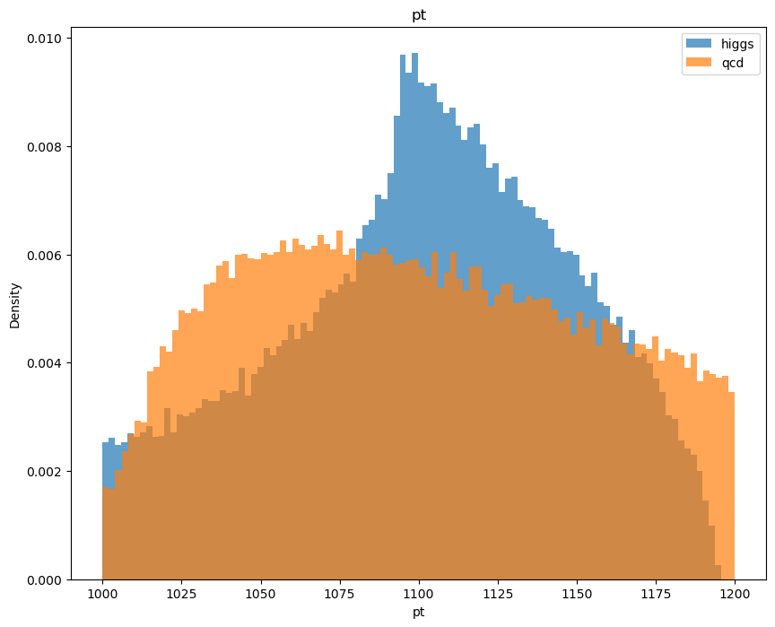

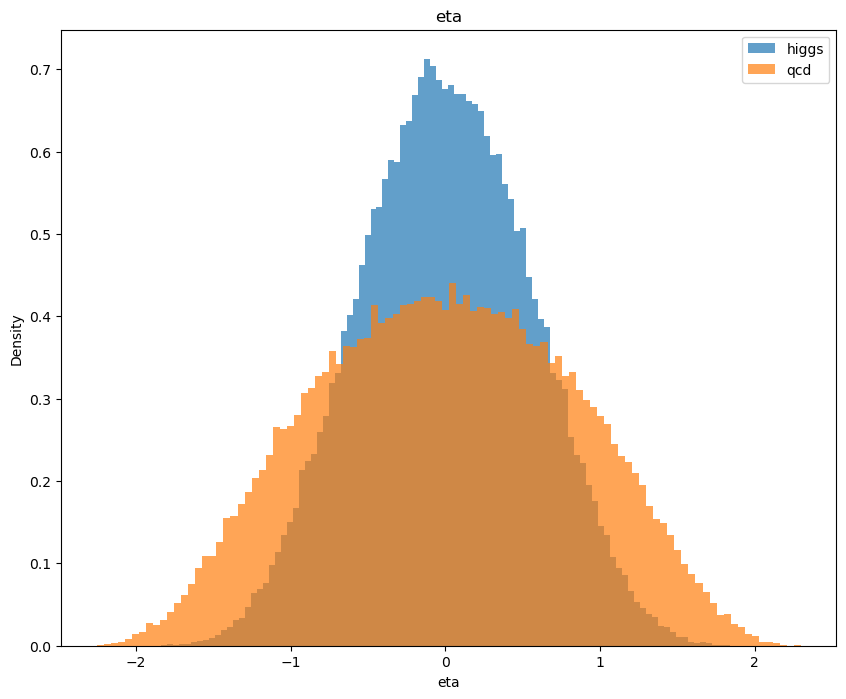

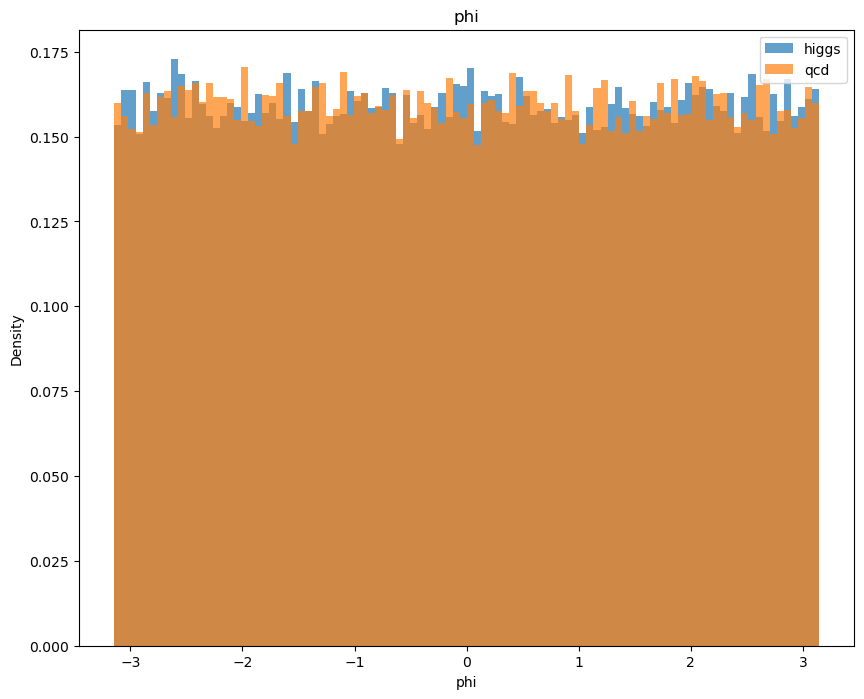

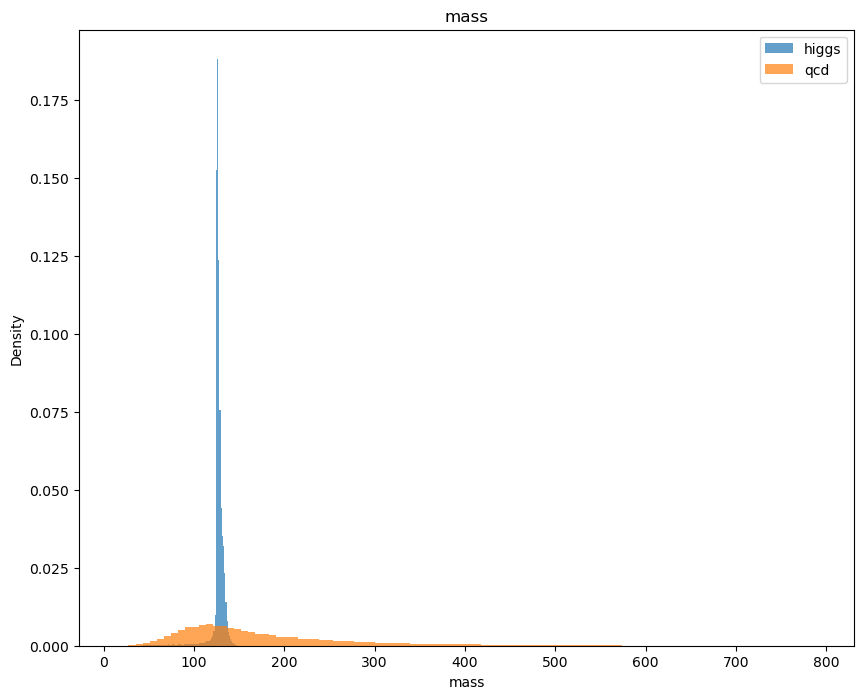

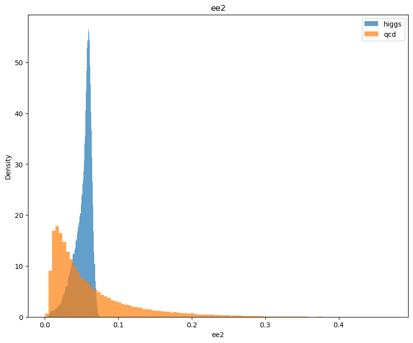

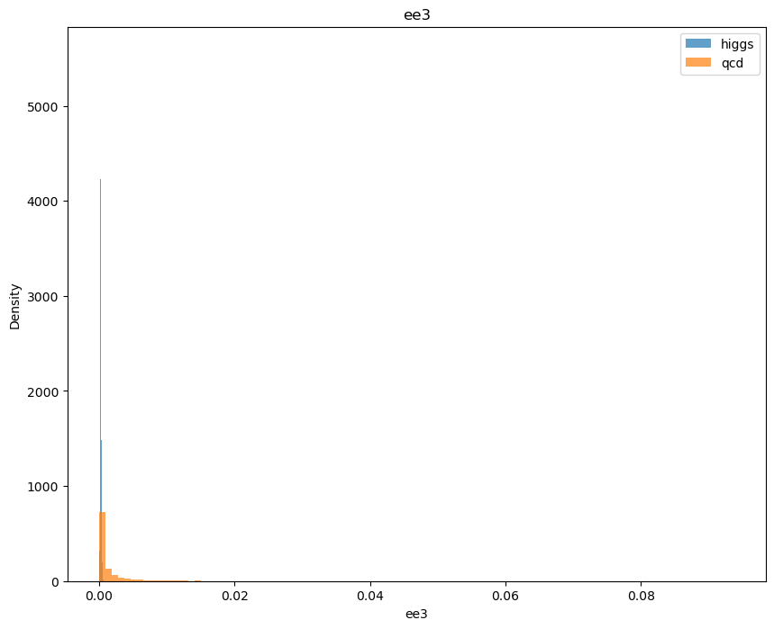

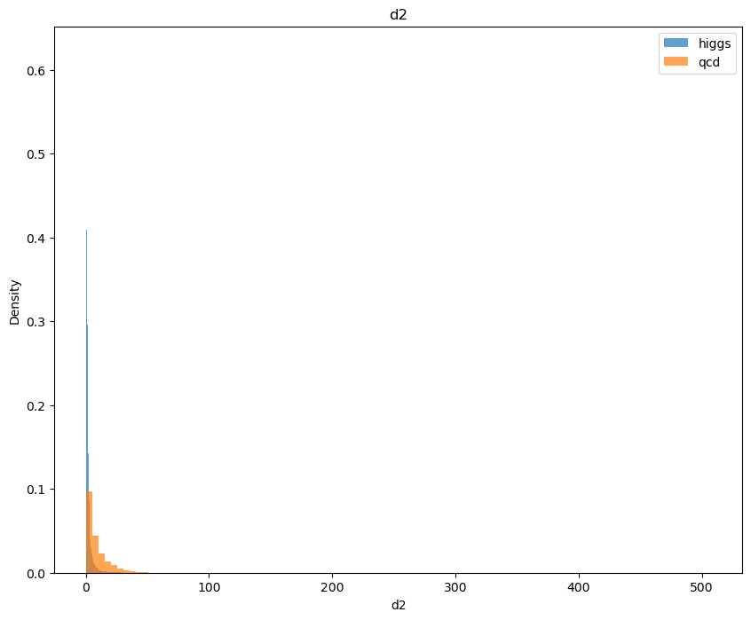

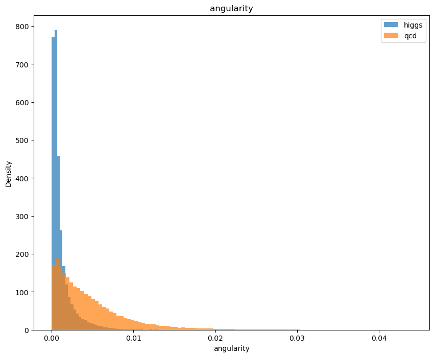

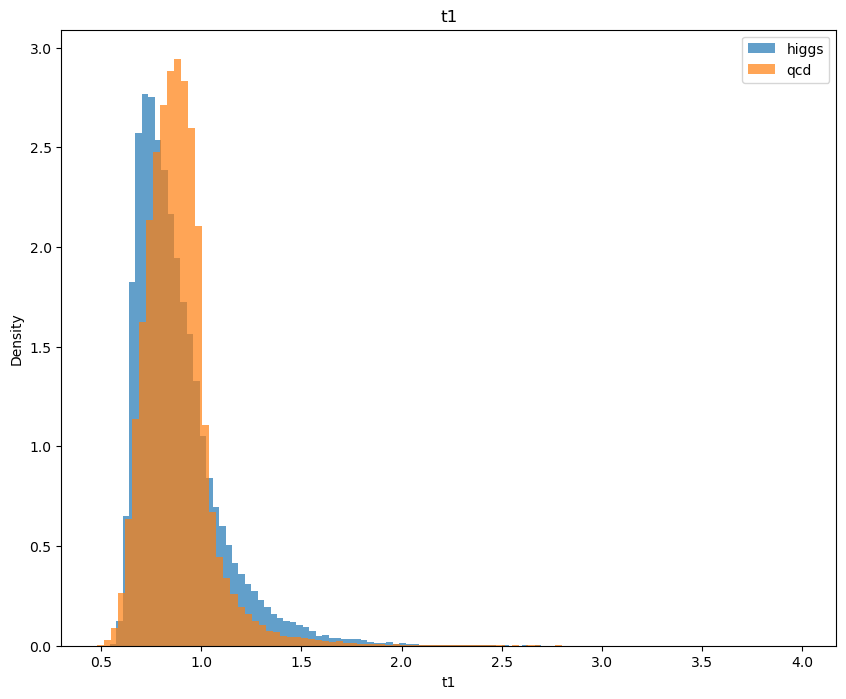

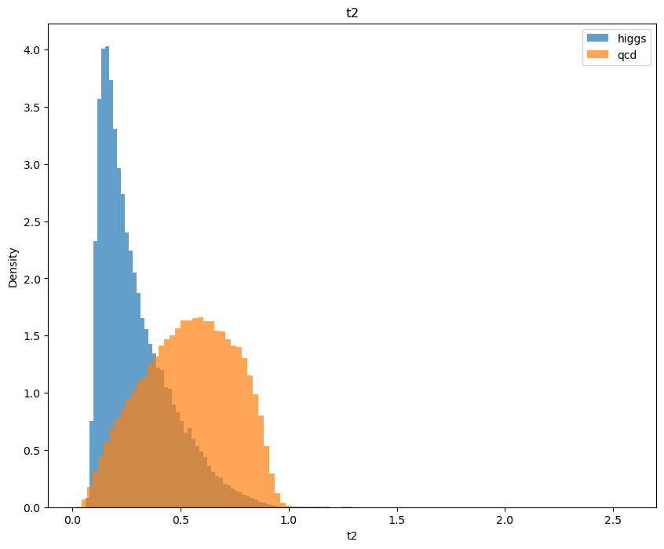

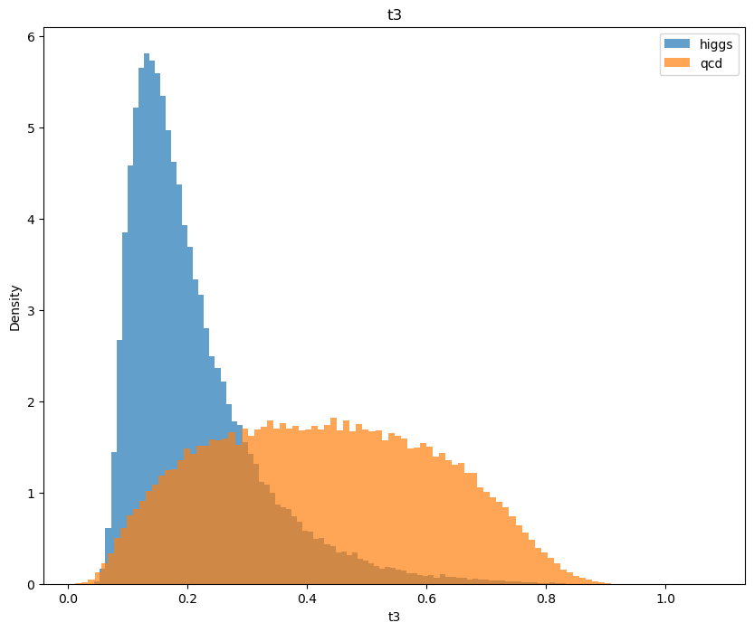

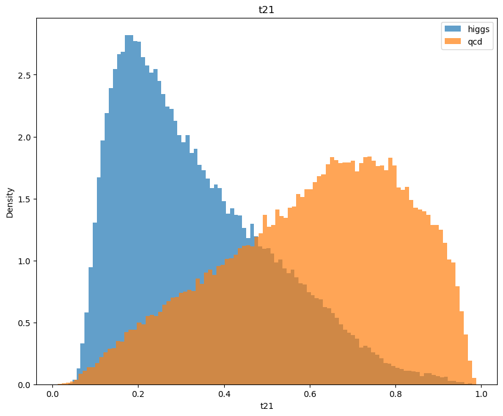

[2 more figures not shown]

```python
for i in range (0, 14):
    Hisplots(higgs.columns[i], higgs.columns[i])
```

We use histograms above to compare each feature of the higgs and the qcd of jets. As we can see, from the graph, mass, ee2, ee3, d2, angularity, t2, t3, t21, and KtDeltaR provide discrimination power between signal and background. pt, eta, and t1 provide a relative weaker discrimination power. phi and t32 provide no discrimination power.

**2. Are there correlations among these features?**

```python
higgs_corr = higgs_dict.corr()
higgs_corr
```

|  | pt | eta | phi | mass | ee2 | ee3 | d2 | angularity | t1 | t2 | t3 | t21 | t32 | KtDeltaR |
| --- | --- | --- | --- | --- | --- | --- | --- | --- | --- | --- | --- | --- | --- | --- |
| pt | 1.000000 | 0.002364 | -0.003848 | 0.036439 | -0.184705 | -0.277540 | 0.003851 | -0.009291 | -0.002860 | -0.003149 | -0.002776 | -0.001212 | 0.003259 | -0.094079 |
| eta | 0.002364 | 1.000000 | 0.003208 | -0.002802 | -0.001038 | -0.008008 | -0.001517 | -0.001784 | -0.003189 | -0.005761 | -0.003167 | -0.004681 | 0.004687 | -0.002573 |
| phi | -0.003848 | 0.003208 | 1.000000 | -0.000300 | 0.000026 | 0.003158 | -0.001594 | 0.000096 | 0.002546 | 0.003754 | 0.005039 | 0.003303 | 0.000293 | -0.000192 |
| mass | 0.036439 | -0.002802 | -0.000300 | 1.000000 | 0.482118 | 0.295623 | -0.657884 | -0.082215 | -0.012772 | -0.361910 | -0.469348 | -0.353449 | -0.062976 | 0.207637 |
| ee2 | -0.184705 | -0.001038 | 0.000026 | 0.482118 | 1.000000 | 0.472587 | -0.762707 | -0.562271 | 0.464036 | -0.298043 | -0.476069 | -0.520490 | -0.247725 | -0.446029 |
| ee3 | -0.277540 | -0.008008 | 0.003158 | 0.295623 | 0.472587 | 1.000000 | -0.193750 | -0.053734 | 0.302605 | 0.538306 | 0.360882 | 0.393229 | -0.507203 | -0.232239 |
| d2 | 0.003851 | -0.001517 | -0.001594 | -0.657884 | -0.762707 | -0.193750 | 1.000000 | 0.551605 | -0.143680 | 0.535725 | 0.668915 | 0.621240 | 0.064989 | 0.145284 |
| angularity | -0.009291 | -0.001784 | 0.000096 | -0.082215 | -0.562271 | -0.053734 | 0.551605 | 1.000000 | -0.180445 | 0.324004 | 0.413879 | 0.425013 | 0.074085 | 0.291413 |
| t1 | -0.002860 | -0.003189 | 0.002546 | -0.012772 | 0.464036 | 0.302605 | -0.143680 | -0.180445 | 1.000000 | 0.148028 | 0.032836 | -0.189195 | -0.256003 | -0.395682 |
| t2 | -0.003149 | -0.005761 | 0.003754 | -0.361910 | -0.298043 | 0.538306 | 0.535725 | 0.324004 | 0.148028 | 1.000000 | 0.902075 | 0.923238 | -0.472627 | -0.116152 |
| t3 | -0.002776 | -0.003167 | 0.005039 | -0.469348 | -0.476069 | 0.360882 | 0.668915 | 0.413879 | 0.032836 | 0.902075 | 1.000000 | 0.891795 | -0.089714 | -0.039668 |
| t21 | -0.001212 | -0.004681 | 0.003303 | -0.353449 | -0.520490 | 0.393229 | 0.621240 | 0.425013 | -0.189195 | 0.923238 | 0.891795 | 1.000000 | -0.347453 | 0.089134 |
| t32 | 0.003259 | 0.004687 | 0.000293 | -0.062976 | -0.247725 | -0.507203 | 0.064989 | 0.074085 | -0.256003 | -0.472627 | -0.089714 | -0.347453 | 1.000000 | 0.183925 |
| KtDeltaR | -0.094079 | -0.002573 | -0.000192 | 0.207637 | -0.446029 | -0.232239 | 0.145284 | 0.291413 | -0.395682 | -0.116152 | -0.039668 | 0.089134 | 0.183925 | 1.000000 |

```python
pd.DataFrame([(higgs_corr - np.eye(len(higgs_corr))).max(), (higgs_corr - np.eye(len(higgs_corr))).idxmax()]).T
```

|  | 0 | 1 |
| --- | --- | --- |
| pt | 0.036439 | mass |
| eta | 0.004687 | t32 |
| phi | 0.005039 | t3 |
| mass | 0.482118 | ee2 |
| ee2 | 0.482118 | mass |
| ee3 | 0.538306 | t2 |
| d2 | 0.668915 | t3 |
| angularity | 0.551605 | d2 |
| t1 | 0.464036 | ee2 |
| t2 | 0.923238 | t21 |
| t3 | 0.902075 | t2 |
| t21 | 0.923238 | t2 |
| t32 | 0.183925 | KtDeltaR |
| KtDeltaR | 0.291413 | angularity |

```python
qcd_corr = qcd_dict.corr()
qcd_corr
```

|  | pt | eta | phi | mass | ee2 | ee3 | d2 | angularity | t1 | t2 | t3 | t21 | t32 | KtDeltaR |
| --- | --- | --- | --- | --- | --- | --- | --- | --- | --- | --- | --- | --- | --- | --- |
| pt | 1.000000 | 0.000083 | -0.006469 | 0.095461 | 0.012772 | 0.006981 | -0.003817 | 0.032309 | -0.010783 | -0.027798 | -0.033102 | -0.027596 | -0.024690 | 0.024390 |
| eta | 0.000083 | 1.000000 | 0.001784 | 0.000767 | 0.000499 | 0.001447 | -0.002371 | 0.000908 | -0.002803 | -0.001568 | -0.001840 | -0.000351 | -0.000405 | -0.002086 |
| phi | -0.006469 | 0.001784 | 1.000000 | -0.005159 | -0.003282 | -0.003464 | 0.001273 | -0.008891 | 0.002601 | 0.000465 | 0.001326 | -0.000321 | 0.002848 | -0.003087 |
| mass | 0.095461 | 0.000767 | -0.005159 | 1.000000 | 0.959965 | 0.793991 | -0.538750 | 0.529638 | 0.010450 | -0.533355 | -0.621826 | -0.585519 | -0.459640 | 0.708356 |
| ee2 | 0.012772 | 0.000499 | -0.003282 | 0.959965 | 1.000000 | 0.844699 | -0.567445 | 0.427854 | 0.126657 | -0.517926 | -0.620038 | -0.613574 | -0.495083 | 0.614471 |
| ee3 | 0.006981 | 0.001447 | -0.003464 | 0.793991 | 0.844699 | 1.000000 | -0.306321 | 0.433308 | 0.138780 | -0.250764 | -0.350501 | -0.323984 | -0.412092 | 0.459877 |
| d2 | -0.003817 | -0.002371 | 0.001273 | -0.538750 | -0.567445 | -0.306321 | 1.000000 | -0.184381 | -0.022127 | 0.554533 | 0.622112 | 0.619491 | 0.325022 | -0.392433 |
| angularity | 0.032309 | 0.000908 | -0.008891 | 0.529638 | 0.427854 | 0.433308 | -0.184381 | 1.000000 | -0.052497 | -0.152266 | -0.196199 | -0.155062 | -0.190053 | 0.406357 |
| t1 | -0.010783 | -0.002803 | 0.002601 | 0.010450 | 0.126657 | 0.138780 | -0.022127 | -0.052497 | 1.000000 | 0.326725 | 0.238284 | -0.002957 | -0.146209 | -0.271773 |
| t2 | -0.027798 | -0.001568 | 0.000465 | -0.533355 | -0.517926 | -0.250764 | 0.554533 | -0.152266 | 0.326725 | 1.000000 | 0.936640 | 0.926364 | 0.129887 | -0.635300 |
| t3 | -0.033102 | -0.001840 | 0.001326 | -0.621826 | -0.620038 | -0.350501 | 0.622112 | -0.196199 | 0.238284 | 0.936640 | 1.000000 | 0.897178 | 0.443389 | -0.639734 |
| t21 | -0.027596 | -0.000351 | -0.000321 | -0.585519 | -0.613574 | -0.323984 | 0.619491 | -0.155062 | -0.002957 | 0.926364 | 0.897178 | 1.000000 | 0.194428 | -0.572633 |
| t32 | -0.024690 | -0.000405 | 0.002848 | -0.459640 | -0.495083 | -0.412092 | 0.325022 | -0.190053 | -0.146209 | 0.129887 | 0.443389 | 0.194428 | 1.000000 | -0.222624 |
| KtDeltaR | 0.024390 | -0.002086 | -0.003087 | 0.708356 | 0.614471 | 0.459877 | -0.392433 | 0.406357 | -0.271773 | -0.635300 | -0.639734 | -0.572633 | -0.222624 | 1.000000 |

```python
pd.DataFrame([(qcd_corr - np.eye(len(qcd_corr))).max(), (qcd_corr - np.eye(len(qcd_corr))).idxmax()]).T
```

|  | 0 | 1 |
| --- | --- | --- |
| pt | 0.095461 | mass |
| eta | 0.001784 | phi |
| phi | 0.002848 | t32 |
| mass | 0.959965 | ee2 |
| ee2 | 0.959965 | mass |
| ee3 | 0.844699 | ee2 |
| d2 | 0.622112 | t3 |
| angularity | 0.529638 | mass |
| t1 | 0.326725 | t2 |
| t2 | 0.93664 | t3 |
| t3 | 0.93664 | t2 |
| t21 | 0.926364 | t2 |
| t32 | 0.443389 | t3 |
| KtDeltaR | 0.708356 | mass |

Yes, there are correlations among thoses features. For higgs dataset, t21 and t2, t3 and t2 have high correlation. For qcd dataset, mass and ee2, ee3 and ee2, t2 and t3, t21 and t2 have high correlations.

**3. Compute the expected discovery sensitivity (significance of the expected signal) by normalizing each sample appropriately (see 'expected yields' below).**

The expected yields: $N_{higgs} = 100$ and $N_{qcd} = 20000$, so with the poisson distribution background, $\lambda = 20000$ and the Higgs Boson signal will be $20100$

```python
prob = stats.poisson.sf(20100, 20000)
sigma = stats.norm.isf(prob)
sigma
```

```
0.7112259282313185
```

We want to see what signal will have a sigma value 5 or more.

```python
prob = stats.norm.sf(5)
signal = stats.poisson.isf(prob, 20000)
signal
```

```
20711.0
```

**4. Develop a plan to optimize the discovery sensitivity by applying selections to these features.**

we compare the background and signal distributions to see if we can remove some of the background data outside the signal.